# 05: `tidyr`

## Pregunta 1

Considere los datos y calcule:

```r
library(tidyverse)

ddesempleo <- economics |>
  select(fecha = date, desempleo = uempmed) |>
  filter(year(fecha) > 2005)

glimpse(ddesempleo)
```

```
Rows: 112
Columns: 2
$ fecha     <date> 2006-01-01, 2006-02-01, 2006-03-01, 2006-04-01, 2006-05-01,…
$ desempleo <dbl> 8.6, 9.1, 8.7, 8.4, 8.5, 7.3, 8.0, 8.4, 8.0, 7.9, 8.3, 7.5, …
```

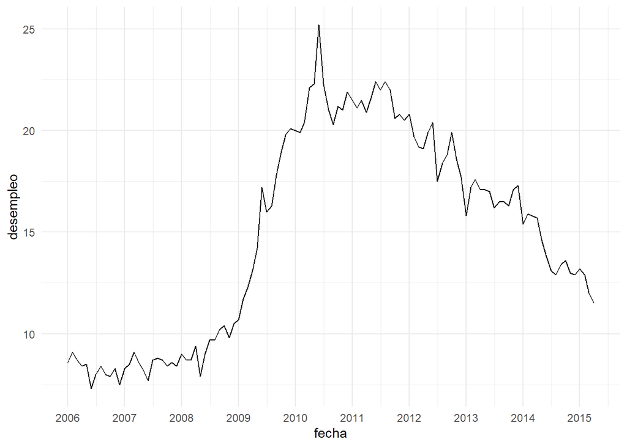

```r
ggplot(ddesempleo) +
  geom_line(aes(fecha, desempleo)) +
  scale_x_date(breaks = "year", date_labels = "%Y") +
  theme_minimal()
```

1. La variación porcentual de la tasa de desempleo respecto al mes anterior
2. La variación porcentual respecto al mismo mes del año anterior.
3. La variación porcentual respecto a diciembre del año anterior.
4. Crear un gráfico con `ggplot2` mostrando estas 4 series (hint: combo `pivot_longer` + `facet_wrap`).
5. Qué sucede si se intenta hacer lo mismo pero con los siguientes datos? Cual sería una posible solución?

```r
set.seed(123)

ddesempleo2 <- ddesempleo |>
  select(fecha, desempleo) |>
  sample_frac(0.8) |>
  arrange(fecha)

ddesempleo2
```

```
# A tibble: 90 × 2
   fecha      desempleo
   <date>         <dbl>
 1 2006-03-01       8.7
 2 2006-04-01       8.4
 3 2006-05-01       8.5
 4 2006-06-01       7.3
 5 2006-07-01       8
 6 2006-08-01       8.4
 7 2006-09-01       8
 8 2006-12-01       7.5
 9 2007-01-01       8.3
10 2007-02-01       8.5
# … with 80 more rows
```

### Solución

```r
ddesempleo <- ddesempleo |>
  mutate(
    valor_mes_anterior = lag(desempleo), # explicito sería lag(desempleo, n= 1)
    variación_mensual = desempleo/valor_mes_anterior - 1
    )

ddesempleo
```

```
# A tibble: 112 × 4
   fecha      desempleo valor_mes_anterior variación_mensual
   <date>         <dbl>              <dbl>             <dbl>
 1 2006-01-01       8.6               NA             NA
 2 2006-02-01       9.1                8.6            0.0581
 3 2006-03-01       8.7                9.1           -0.0440
 4 2006-04-01       8.4                8.7           -0.0345
 5 2006-05-01       8.5                8.4            0.0119
 6 2006-06-01       7.3                8.5           -0.141
 7 2006-07-01       8                  7.3            0.0959
 8 2006-08-01       8.4                8              0.0500
 9 2006-09-01       8                  8.4           -0.0476
10 2006-10-01       7.9                8             -0.0125
# … with 102 more rows
```

```r
ddesempleo <- ddesempleo |>
  mutate(
    valor_anio_anterior = lag(desempleo, n = 12),
    variación_anual = desempleo/valor_anio_anterior - 1
    )

ddesempleo
```

```
# A tibble: 112 × 6
   fecha      desempleo valor_mes_anterior variación_mensual valor_ani…¹ varia…²
   <date>         <dbl>              <dbl>             <dbl>       <dbl>   <dbl>
 1 2006-01-01       8.6               NA             NA               NA      NA
 2 2006-02-01       9.1                8.6            0.0581          NA      NA
 3 2006-03-01       8.7                9.1           -0.0440          NA      NA
 4 2006-04-01       8.4                8.7           -0.0345          NA      NA
 5 2006-05-01       8.5                8.4            0.0119          NA      NA
 6 2006-06-01       7.3                8.5           -0.141           NA      NA
 7 2006-07-01       8                  7.3            0.0959          NA      NA
 8 2006-08-01       8.4                8              0.0500          NA      NA
 9 2006-09-01       8                  8.4           -0.0476          NA      NA
10 2006-10-01       7.9                8             -0.0125          NA      NA
# … with 102 more rows, and abbreviated variable names ¹valor_anio_anterior,
#   ²variación_anual
```

```r
tail(ddesempleo, 10)
```

```
# A tibble: 10 × 6
   fecha      desempleo valor_mes_anterior variación_mensual valor_ani…¹ varia…²
   <date>         <dbl>              <dbl>             <dbl>       <dbl>   <dbl>
 1 2014-07-01      13.1               13.8          -0.0507         16.2  -0.191
 2 2014-08-01      12.9               13.1          -0.0153         16.5  -0.218
 3 2014-09-01      13.4               12.9           0.0388         16.5  -0.188
 4 2014-10-01      13.6               13.4           0.0149         16.3  -0.166
 5 2014-11-01      13                 13.6          -0.0441         17.1  -0.240
 6 2014-12-01      12.9               13            -0.00769        17.3  -0.254
 7 2015-01-01      13.2               12.9           0.0233         15.4  -0.143
 8 2015-02-01      12.9               13.2          -0.0227         15.9  -0.189
 9 2015-03-01      12                 12.9          -0.0698         15.8  -0.241
10 2015-04-01      11.5               12            -0.0417         15.7  -0.268
# … with abbreviated variable names ¹valor_anio_anterior, ²variación_anual
```

3. Podemos utilizar una data auxiliar que tenga los diciembres, luego hacer join por anio.

```r
# d   de data
# des de desempleo
# dic de diciembre
ddesdic <- ddesempleo |>
  filter(month(fecha) == 12) |>
  mutate(anio = year(fecha)) |>
  select(anio, desempleo_dic = desempleo)

ddesdic
```

```
# A tibble: 9 × 2
   anio desempleo_dic
  <dbl>         <dbl>
1  2006           7.5
2  2007           8.4
3  2008          10.5
4  2009          20.1
5  2010          21.9
6  2011          20.5
7  2012          17.7
8  2013          17.3
9  2014          12.9
```

```r
ddesempleo <- ddesempleo |>
  mutate(anio_anterior = year(fecha) - 1) |>
  left_join(ddesdic, by = join_by(anio_anterior == anio)) |>
  mutate(
    variación_dic_anterior = desempleo/desempleo_dic - 1
    )

glimpse(ddesempleo)
```

```
Rows: 112
Columns: 9
$ fecha                  <date> 2006-01-01, 2006-02-01, 2006-03-01, 2006-04-01…
$ desempleo              <dbl> 8.6, 9.1, 8.7, 8.4, 8.5, 7.3, 8.0, 8.4, 8.0, 7.…
$ valor_mes_anterior     <dbl> NA, 8.6, 9.1, 8.7, 8.4, 8.5, 7.3, 8.0, 8.4, 8.0…
$ variación_mensual      <dbl> NA, 0.05813953, -0.04395604, -0.03448276, 0.011…
$ valor_anio_anterior    <dbl> NA, NA, NA, NA, NA, NA, NA, NA, NA, NA, NA, NA,…
$ variación_anual        <dbl> NA, NA, NA, NA, NA, NA, NA, NA, NA, NA, NA, NA,…
$ anio_anterior          <dbl> 2005, 2005, 2005, 2005, 2005, 2005, 2005, 2005,…
$ desempleo_dic          <dbl> NA, NA, NA, NA, NA, NA, NA, NA, NA, NA, NA, NA,…
$ variación_dic_anterior <dbl> NA, NA, NA, NA, NA, NA, NA, NA, NA, NA, NA, NA,…
```

```r
ddesempleo <- ddesempleo |>
  select(fecha, desempleo, starts_with("variación"))

tail(ddesempleo)
```

```
# A tibble: 6 × 5
  fecha      desempleo variación_mensual variación_anual variación_dic_anterior
  <date>         <dbl>             <dbl>           <dbl>                  <dbl>
1 2014-11-01      13            -0.0441           -0.240                -0.249
2 2014-12-01      12.9          -0.00769          -0.254                -0.254
3 2015-01-01      13.2           0.0233           -0.143                 0.0233
4 2015-02-01      12.9          -0.0227           -0.189                 0
5 2015-03-01      12            -0.0698           -0.241                -0.0698
6 2015-04-01      11.5          -0.0417           -0.268                -0.109
```

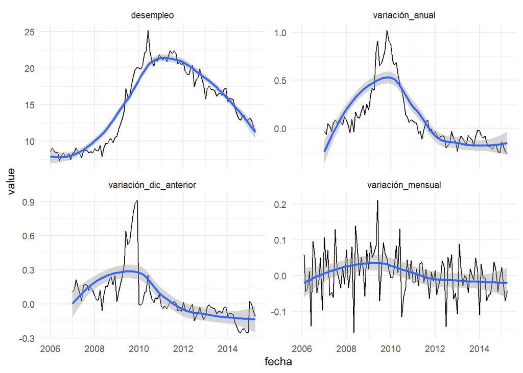

```r
ddesempleo_long <- pivot_longer(ddesempleo, cols = -fecha)

ggplot(ddesempleo_long, aes(fecha, value, group = name)) +
  geom_line() +
  geom_smooth() +
  facet_wrap(vars(name), scales = "free_y") +
  theme_minimal()
```

5. 😱😱😱😱😱

## Pregunta 2

Considere los datos de `vuelos` y `aeropuertos` del paquete datos:

1. Simplifique las tablas seleccionado para `vuelos` las columnas `origen`, `destino` y para `aeropuertos` las columnas `codigo_aeropuerto`, `latitud` y `longitud`:
2. De la tabla de vuelos obtenga la cantidad de vuelos realizados para cada par `origen` `destino`.
3. A la tabla anterior incluya las posición geográfica tanto del origen como del destino utilizando la tabla `aeropuertos`, considere luego solamente los casos “completos” (sin `NA`s).
4. En un mapa muestre los 10 vuelos más largos, y los 10 vuelos más recurrentes.

### Solución

```r
library(datos)
vuelos <- select(vuelos, fecha_hora, origen, destino)
vuelos
```

```
# A tibble: 336,776 × 3
   fecha_hora          origen destino
   <dttm>              <chr>  <chr>
 1 2013-01-01 05:00:00 EWR    IAH
 2 2013-01-01 05:00:00 LGA    IAH
 3 2013-01-01 05:00:00 JFK    MIA
 4 2013-01-01 05:00:00 JFK    BQN
 5 2013-01-01 06:00:00 LGA    ATL
 6 2013-01-01 05:00:00 EWR    ORD
 7 2013-01-01 06:00:00 EWR    FLL
 8 2013-01-01 06:00:00 LGA    IAD
 9 2013-01-01 06:00:00 JFK    MCO
10 2013-01-01 06:00:00 LGA    ORD
# … with 336,766 more rows
```

```r
aeropuertos <- select(aeropuertos, codigo_aeropuerto, latitud, longitud)
aeropuertos
```

```
# A tibble: 1,458 × 3
   codigo_aeropuerto latitud longitud
   <chr>               <dbl>    <dbl>
 1 04G                  41.1    -80.6
 2 06A                  32.5    -85.7
 3 06C                  42.0    -88.1
 4 06N                  41.4    -74.4
 5 09J                  31.1    -81.4
 6 0A9                  36.4    -82.2
 7 0G6                  41.5    -84.5
 8 0G7                  42.9    -76.8
 9 0P2                  39.8    -76.6
10 0S9                  48.1   -123.
# … with 1,448 more rows
```

```r
vuelos_conteos <- vuelos |>
  group_by(origen, destino) |>
  summarise(viajes = n(), .groups = "drop")

# drop es para que la tabla no que _agrupada_
vuelos_conteos
```

```
# A tibble: 224 × 3
   origen destino viajes
   <chr>  <chr>    <int>
 1 EWR    ALB        439
 2 EWR    ANC          8
 3 EWR    ATL       5022
 4 EWR    AUS        968
 5 EWR    AVL        265
 6 EWR    BDL        443
 7 EWR    BNA       2336
 8 EWR    BOS       5327
 9 EWR    BQN        297
10 EWR    BTV        931
# … with 214 more rows
```

```r
vuelos_conteos <- vuelos_conteos |>
  left_join(aeropuertos, by = join_by(origen  == codigo_aeropuerto)) |>
  left_join(aeropuertos, by = join_by(destino == codigo_aeropuerto), suffix = c("_ori", "_des"))

vuelos_conteos
```

```
# A tibble: 224 × 7
   origen destino viajes latitud_ori longitud_ori latitud_des longitud_des
   <chr>  <chr>    <int>       <dbl>        <dbl>       <dbl>        <dbl>
 1 EWR    ALB        439        40.7        -74.2        42.7        -73.8
 2 EWR    ANC          8        40.7        -74.2        61.2       -150.
 3 EWR    ATL       5022        40.7        -74.2        33.6        -84.4
 4 EWR    AUS        968        40.7        -74.2        30.2        -97.7
 5 EWR    AVL        265        40.7        -74.2        35.4        -82.5
 6 EWR    BDL        443        40.7        -74.2        41.9        -72.7
 7 EWR    BNA       2336        40.7        -74.2        36.1        -86.7
 8 EWR    BOS       5327        40.7        -74.2        42.4        -71.0
 9 EWR    BQN        297        40.7        -74.2        NA           NA
10 EWR    BTV        931        40.7        -74.2        44.5        -73.2
# … with 214 more rows
```

```r
vuelos_conteos <- vuelos_conteos |>
  filter(complete.cases(vuelos_conteos))
```

4. Acá se intentan 3 formas de obtener distancia, 2 con el paquete geodist y una con pitágoras no más, pues lo que importa es la magnitud.

```r
library(geodist)

geodist_mts_tidy <- function(lat1 = 40.7, lon1 = -74.2, lat2 = 42.7, lon2 = -73.8){

  x <- matrix(c(lon1, lat1), nrow = 1, dimnames = list(NULL, c("x", "y")))
  y <- matrix(c(lon2, lat2), nrow = 1, dimnames = list(NULL, c("x", "y")))

  as.numeric(geodist(x, y, measure =  "haversine"))

}

geodist_mts_tidy <- Vectorize(geodist_mts_tidy)

distancias <- geodist(
  vuelos_conteos |> select(x = longitud_ori, y = latitud_ori) |> as.matrix(),
  vuelos_conteos |> select(x = longitud_des, y = latitud_des) |> as.matrix(),
  measure =  "haversine"
  )[1, ]

vuelos_conteos <- vuelos_conteos |>
  mutate(
    distancia  = geodist_mts_tidy(latitud_ori, longitud_ori, latitud_des, longitud_des),
    distancia2 = distancias,
    distancia3 = sqrt((longitud_ori - longitud_des)^2 + (latitud_ori - latitud_des)^2)
  )

vuelos_conteos
```

```
# A tibble: 217 × 10
   origen destino viajes latit…¹ longi…² latit…³ longi…⁴ dista…⁵ dista…⁶ dista…⁷
   <chr>  <chr>    <int>   <dbl>   <dbl>   <dbl>   <dbl>   <dbl>   <dbl>   <dbl>
 1 EWR    ALB        439    40.7   -74.2    42.7   -73.8  2.31e5  2.31e5    2.09
 2 EWR    ANC          8    40.7   -74.2    61.2  -150.   5.42e6  5.42e6   78.5
 3 EWR    ATL       5022    40.7   -74.2    33.6   -84.4  1.20e6  1.20e6   12.5
 4 EWR    AUS        968    40.7   -74.2    30.2   -97.7  2.42e6  2.42e6   25.7
 5 EWR    AVL        265    40.7   -74.2    35.4   -82.5  9.38e5  9.38e5    9.89
 6 EWR    BDL        443    40.7   -74.2    41.9   -72.7  1.86e5  1.86e5    1.94
 7 EWR    BNA       2336    40.7   -74.2    36.1   -86.7  1.20e6  1.20e6   13.3
 8 EWR    BOS       5327    40.7   -74.2    42.4   -71.0  3.23e5  3.23e5    3.58
 9 EWR    BTV        931    40.7   -74.2    44.5   -73.2  4.29e5  4.29e5    3.91
10 EWR    BUF        973    40.7   -74.2    42.9   -78.7  4.54e5  4.54e5    5.09
# … with 207 more rows, and abbreviated variable names ¹latitud_ori,
#   ²longitud_ori, ³latitud_des, ⁴longitud_des, ⁵distancia, ⁶distancia2,
#   ⁷distancia3
```

```r
vuelos_top10_largos <- vuelos_conteos |>
  slice_max(order_by = distancia , n = 10) |>
  mutate(tipo = "largo", .before = 1)

vuelos_top10_popular <- vuelos_conteos |>
  slice_max(order_by = viajes, n = 10) |>
  mutate(tipo = "popular", .before = 1)

vuelos_top10 <- union_all(vuelos_top10_largos, vuelos_top10_popular)
vuelos_top10
```

```
# A tibble: 20 × 11
   tipo    origen destino viajes latit…¹ longi…² latit…³ longi…⁴ dista…⁵ dista…⁶
   <chr>   <chr>  <chr>    <int>   <dbl>   <dbl>   <dbl>   <dbl>   <dbl>   <dbl>
 1 largo   JFK    HNL        342    40.6   -73.8    21.3  -158.   8.02e6  7.98e6
 2 largo   EWR    HNL        365    40.7   -74.2    21.3  -158.   7.98e6  7.98e6
 3 largo   EWR    ANC          8    40.7   -74.2    61.2  -150.   5.42e6  5.42e6
 4 largo   JFK    SFO       8204    40.6   -73.8    37.6  -122.   4.16e6  4.12e6
 5 largo   JFK    OAK        312    40.6   -73.8    37.7  -122.   4.14e6  4.11e6
 6 largo   JFK    SJC        329    40.6   -73.8    37.4  -122.   4.13e6  4.10e6
 7 largo   EWR    SFO       5127    40.7   -74.2    37.6  -122.   4.12e6  4.12e6
 8 largo   JFK    SMF        284    40.6   -73.8    38.7  -122.   4.05e6  4.02e6
 9 largo   JFK    LAX      11262    40.6   -73.8    33.9  -118.   3.98e6  3.95e6
10 largo   JFK    BUR        371    40.6   -73.8    34.2  -118.   3.96e6  3.93e6
11 popular JFK    LAX      11262    40.6   -73.8    33.9  -118.   3.98e6  3.95e6
12 popular LGA    ATL      10263    40.8   -73.9    33.6   -84.4  1.23e6  1.20e6
13 popular LGA    ORD       8857    40.8   -73.9    42.0   -87.9  1.18e6  1.16e6
14 popular JFK    SFO       8204    40.6   -73.8    37.6  -122.   4.16e6  4.12e6
15 popular LGA    CLT       6168    40.8   -73.9    35.2   -80.9  8.76e5  8.51e5
16 popular EWR    ORD       6100    40.7   -74.2    42.0   -87.9  1.16e6  1.16e6
17 popular JFK    BOS       5898    40.6   -73.8    42.4   -71.0  3.01e5  3.23e5
18 popular LGA    MIA       5781    40.8   -73.9    25.8   -80.3  1.77e6  1.75e6
19 popular JFK    MCO       5464    40.6   -73.8    28.4   -81.3  1.52e6  1.51e6
20 popular EWR    BOS       5327    40.7   -74.2    42.4   -71.0  3.23e5  3.23e5
# … with 1 more variable: distancia3 <dbl>, and abbreviated variable names
#   ¹latitud_ori, ²longitud_ori, ³latitud_des, ⁴longitud_des, ⁵distancia,
#   ⁶distancia2
```

```r
# ? se repite alguno
vuelos_top10 |>
  count(origen, destino, sort = TRUE) |>
  filter(n > 1)
```

```
# A tibble: 2 × 3
  origen destino     n
  <chr>  <chr>   <int>
1 JFK    LAX         2
2 JFK    SFO         2
```

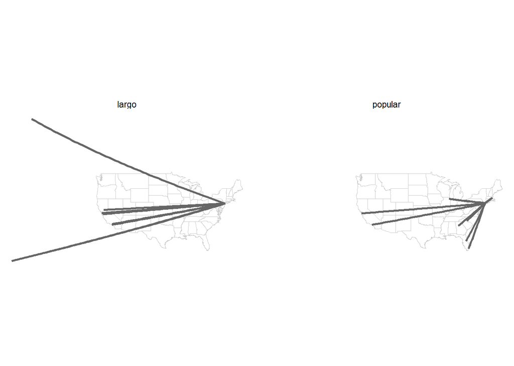

```r
# Los Ángeles, Chile
# San Francisco, Chile

# Ejemplo de clase 5
states <- map_data("state")

ggplot() +
  theme_void() +
  coord_map() +
  geom_polygon(
    data = states,
    aes(long, lat, group = group),
    col = "gray80",
    linewidth = 0.1, fill = NA
    ) +
  geom_segment(
    data = vuelos_top10,
    aes(x = longitud_ori,
        y = latitud_ori,
        xend =  longitud_des ,
        yend = latitud_des),
    col = "gray40", linewidth = 1, alpha = 1
    ) +
  facet_wrap(vars(tipo))
```